# NRG-GY003 WES Analysis

Whole Exome genomic analysis of NRG-GY003 ovarian cancer tumors

Test

Author

Affiliation

Kelsey Monson, PhD, MS

Icahn School of Medicine at Mount Sinai

Published

July 30, 2025

Keywords

R, Data Analysis, Data Viz

# Intro

```r
# Load packages

library(maftools) # For majority of maf file analysis
library(mclust)
library("BSgenome.Hsapiens.UCSC.hg38", quietly = TRUE)
library(NMF) # For signature calculation
library(pheatmap) # For nice heatmaps
library(ghibli) # For pretty colors
```

## Loading in the data

Load in raw MAF file and the clinical data

```r
laml = read.maf(maf="input/merged_consensus_all_samples_germline.maf",
                clinicalData ="input/NRG-GY00_laml_annot_2.csv",
                rmFlags = TRUE # "FLAGS, frequently mutated genes in public exomes"
                )
```

```
-Reading
-Validating
-Removing 20 FLAG genes
-Silent variants: 30668
-Summarizing
-Processing clinical data
-Finished in 3.250s elapsed (2.970s cpu)
```

**Tip**

Setting `rmFlags` = `TRUE` removes frequently mutated genes in public exomes

Details on these genes can be found [here](https://bmcmedgenomics.biomedcentral.com/articles/10.1186/s12920-017-0309-7#MOESM1).

**Setting levels for factor variables**

```r
# RECIST response (CR, PR, SD, PD)
laml@clinical.data$response <- factor(laml@clinical.data$response, levels=c("CR","PR","SD","PD"))
#table(laml@clinical.data$response)

# Detailed response including durable and progressive SD
laml@clinical.data$response2 <- factor(laml@clinical.data$response2, levels=c("CR","PR","SD_CB","SD_NCB","PD"))
# table(laml@clinical.data$response2)

# Response by treatment
laml@clinical.data$response_tx <- factor(laml@clinical.data$response_tx, levels=c("Nivo_CB","Combo_CB","Nivo_NCB","Combo_NCB"))
#table(laml@clinical.data$response_tx)

# Race (White, Non-White, and Not Reported)
laml@clinical.data$race2 <- factor(laml@clinical.data$race2, levels=c("W","NW","NR"))
#table(laml@clinical.data$race2)

# Site (dichotomous)
laml@clinical.data$Site2 <- factor(laml@clinical.data$Site2, levels=c("Adnexa","Non_Adnexa"))
#table(laml@clinical.data$Site2)

# Primary/Met
laml@clinical.data$Primary_Met <- factor(laml@clinical.data$Primary_Met, levels=c("P","M"))
#table(laml@clinical.data$Primary_Met)
```

## Subsetting datasets

We have some normal samples with no matched tumor, and we may be interested in doing subtype-specific analysis.

Let’s subset to only tumor samples, and then create further subsetted datasets based on clinical characteristics.

### Only tumor samples

I also annotated with pathogenic germline variants; the only relevant ones were in BRCA1 and BRCA2, so we are subsetting to somatic mutations and pathogenic germline variants.

```r
laml_tum = subsetMaf(maf = laml, clinQuery = "Tissue %in% 'Tu'")
```

```
-subsetting by clinical data..
```

```
--86 samples meet the clinical query
```

```
-Processing clinical data
```

```r
laml_tum = subsetMaf(maf = laml_tum, query = "vcf_id %in% c('SOMATIC','GERMLINE_PATHOGENIC') ")
```

```
-Processing clinical data
```

### Other subsets

We can also subset by tumor histology, treatment, and response.

**See other subsets**

```r
## Comparing Serous vs others
laml_ser = subsetMaf(maf = laml_tum, clinQuery = "celltype %in% 'Serous_Adenocarcinoma'")
```

```
-subsetting by clinical data..
```

```
--71 samples meet the clinical query
```

```
-Processing clinical data
```

```r
# Subsetting the other dataset to "not serous"
`%ni%` <- Negate(`%in%`)
laml_other = subsetMaf(maf = laml_tum, clinQuery = "celltype %ni% 'Serous_Adenocarcinoma'")
```

```
-subsetting by clinical data..
```

```
--15 samples meet the clinical query
```

```
-Processing clinical data
```

```r
## Comparing CB vs NCB
laml_CB = subsetMaf(maf = laml_tum, clinQuery = "responseCB %in% 'CB'")
```

```
-subsetting by clinical data..
```

```
--29 samples meet the clinical query
```

```
-Processing clinical data
```

```r
laml_NCB = subsetMaf(maf = laml_tum, clinQuery = "responseCB %in% 'NCB'")
```

```
-subsetting by clinical data..
```

```
--57 samples meet the clinical query
```

```
-Processing clinical data
```

```r
## Subsetting by treatment to see if there are differences
### There shouldn't be any, since treatment assignment was randomized, but is is good to confirm.
laml_nivo = subsetMaf(maf = laml_tum, clinQuery = "tx %in% 'Nivo'")
```

```
-subsetting by clinical data..
```

```
--43 samples meet the clinical query
```

```
-Processing clinical data
```

```r
laml_combo = subsetMaf(maf = laml_tum, clinQuery = "tx %in% 'Combo'")
```

```
-subsetting by clinical data..
--43 samples meet the clinical query
```

```
-Processing clinical data
```

## View the MAF file summary

Here is a basic summary of the MAF file

```r
laml_tum
```

```
An object of class  MAF
                        ID summary    Mean Median
                    <char>  <char>   <num>  <num>
 1:             NCBI_Build  GRCh38      NA     NA
 2:                 Center       .      NA     NA
 3:                Samples      86      NA     NA
 4:                 nGenes    6897      NA     NA
 5:        Frame_Shift_Del     234   2.721    2.0
 6:        Frame_Shift_Ins      43   0.500    0.0
 7:           In_Frame_Del      83   0.965    0.0
 8:           In_Frame_Ins       6   0.070    0.0
 9:      Missense_Mutation    9193 106.895   81.0
10:      Nonsense_Mutation     524   6.093    4.0
11:       Nonstop_Mutation      13   0.151    0.0
12:            Splice_Site     505   5.872    3.0
13: Translation_Start_Site      19   0.221    0.0
14:                  total   10620 123.488   92.5
```

**These are some more summaries you can generate**

```r
# I'm commenting them out as they have too much info for the tables to be readable.

# #Shows sample summary.
# getSampleSummary(laml_tum)

# #Shows gene summary.
# getGeneSummary(laml_tum)

# #shows clinical data associated with samples
# getClinicalData(laml_tum)

# #Shows all fields in MAF
# getFields(laml_tum)
```

# Visualization

## Summarize the maf file

We can use `plotmafSummary` to plot the summary of the maf file, which displays number of variants in each sample as a stacked barplot and variant types as a boxplot summarized by `Variant_Classification`.

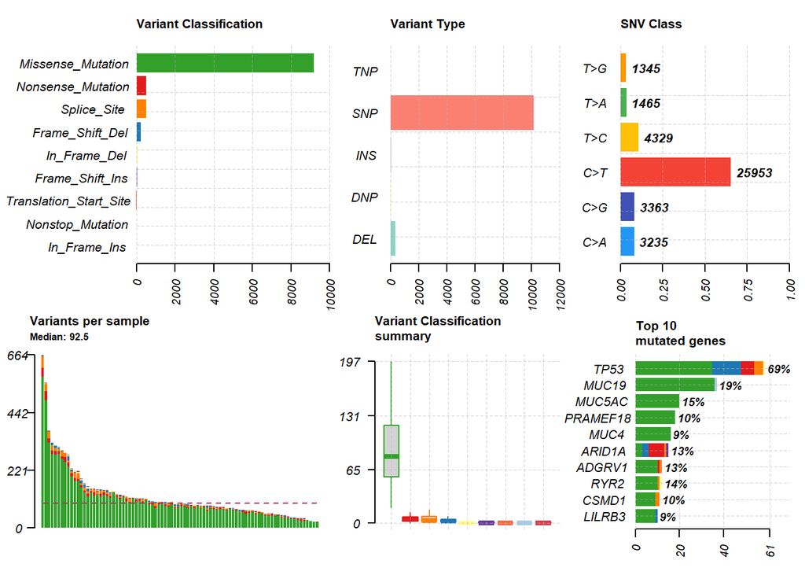

```r
plotmafSummary(maf = laml_tum, rmOutlier = TRUE, addStat = 'median', dashboard = TRUE, titvRaw = FALSE)
```

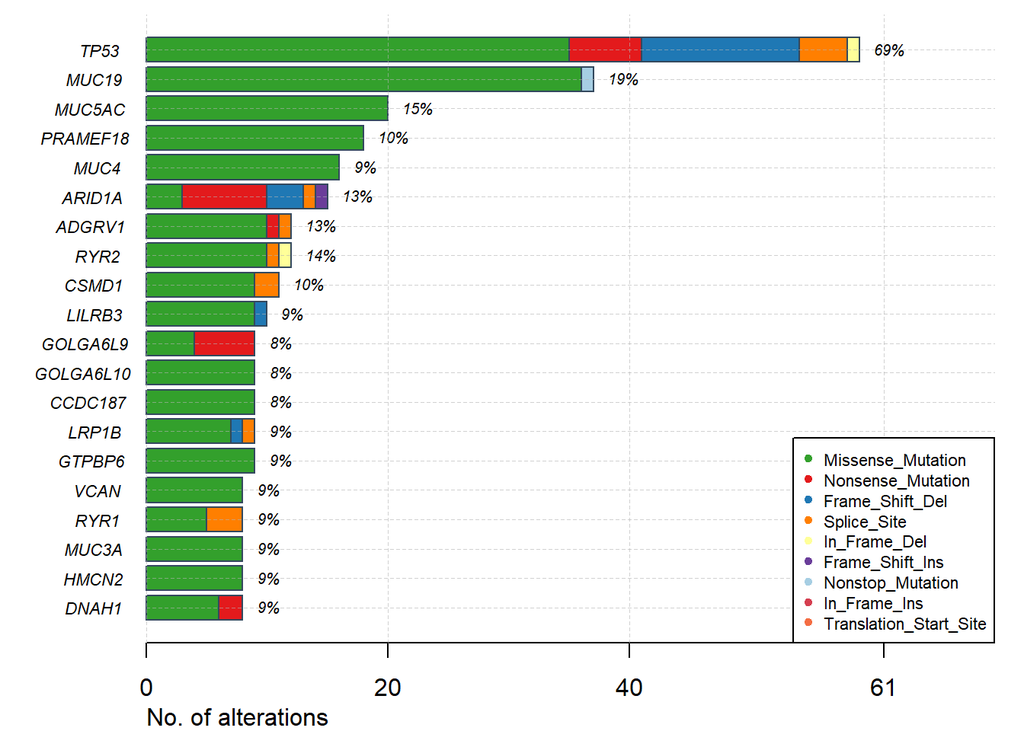

```r
#Use mafbarplot for a minimal barplot of mutated genes.
mafbarplot(maf =  laml_tum)
```

## Summarize the other subsets

Here are the mutation distributions for the other subsets.

As a sanity check, the majority of Serous samples have TP53 mutations, while there are few TP53 mutations in the top 10 for the non-Serous samples (as is expected).

**See the other subsets**

#### By Histology

##### Serous

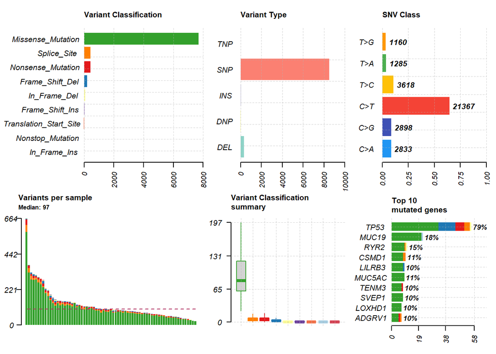

```r
## Serous
plotmafSummary(maf = laml_ser, rmOutlier = TRUE, addStat = 'median', dashboard = TRUE, titvRaw = FALSE)
```

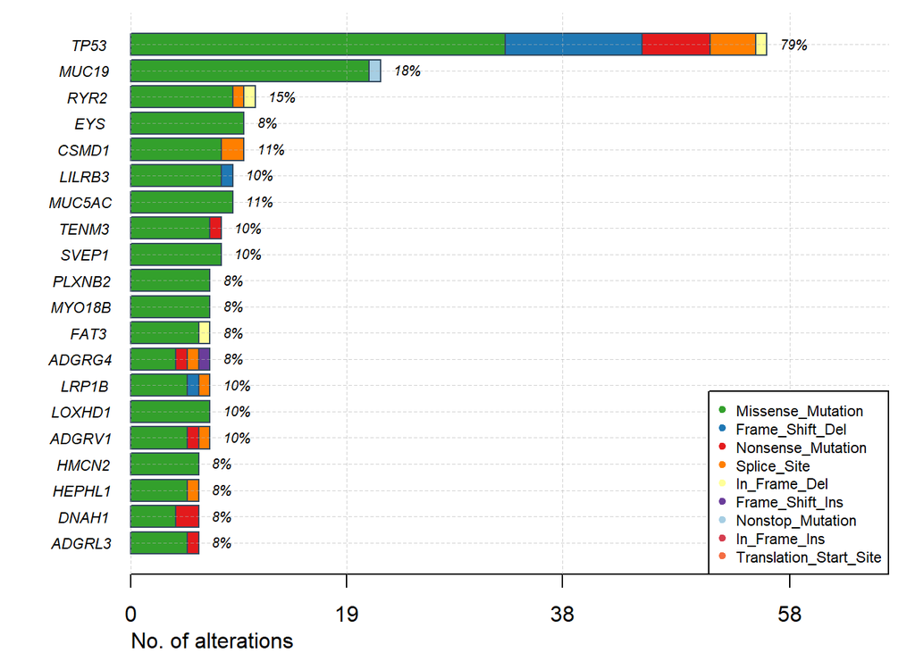

```r
mafbarplot(maf =  laml_ser)
```

##### Non-Serous

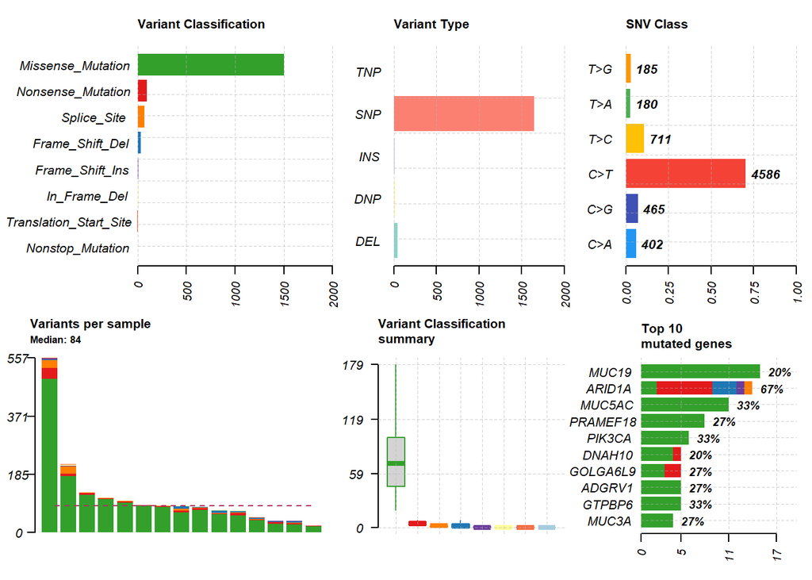

```r
## Non-serous
plotmafSummary(maf = laml_other, rmOutlier = TRUE, addStat = 'median', dashboard = TRUE, titvRaw = FALSE)
```

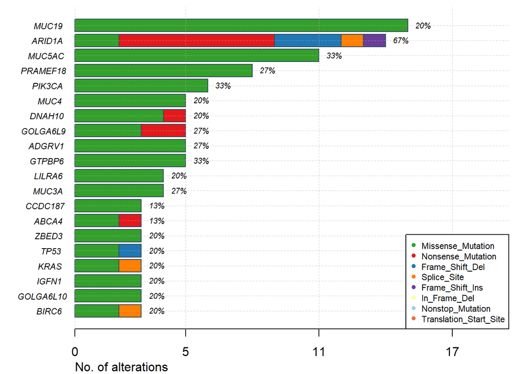

```r
mafbarplot(maf =  laml_other)
```

#### By Response

##### CB

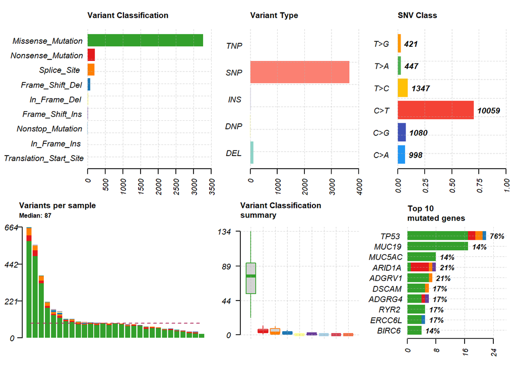

```r
## CB
plotmafSummary(maf = laml_CB, rmOutlier = TRUE, addStat = 'median', dashboard = TRUE, titvRaw = FALSE)
```

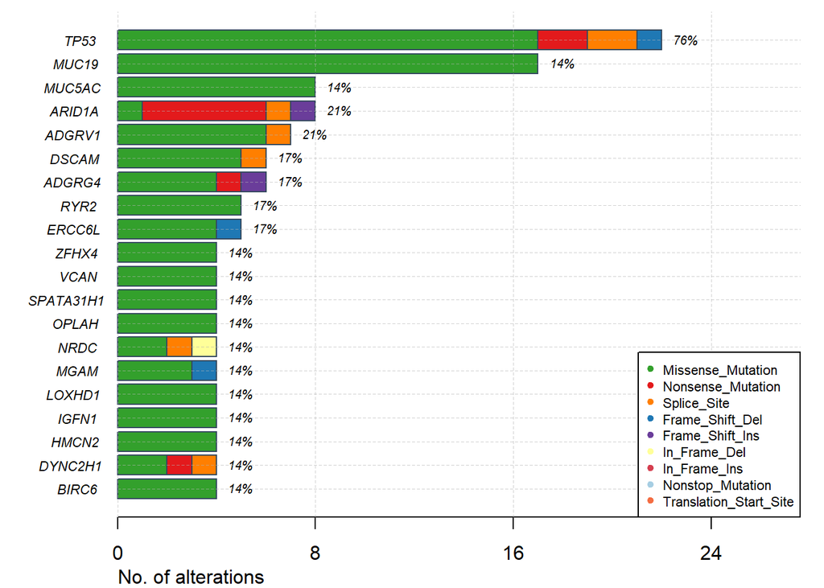

```r
mafbarplot(maf =  laml_CB)
```

##### NCB

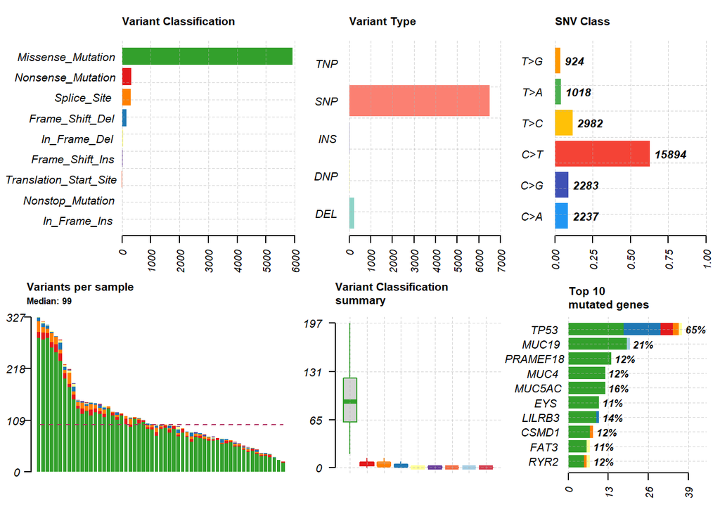

```r
## NCB
plotmafSummary(maf = laml_NCB, rmOutlier = TRUE, addStat = 'median', dashboard = TRUE, titvRaw = FALSE)
```

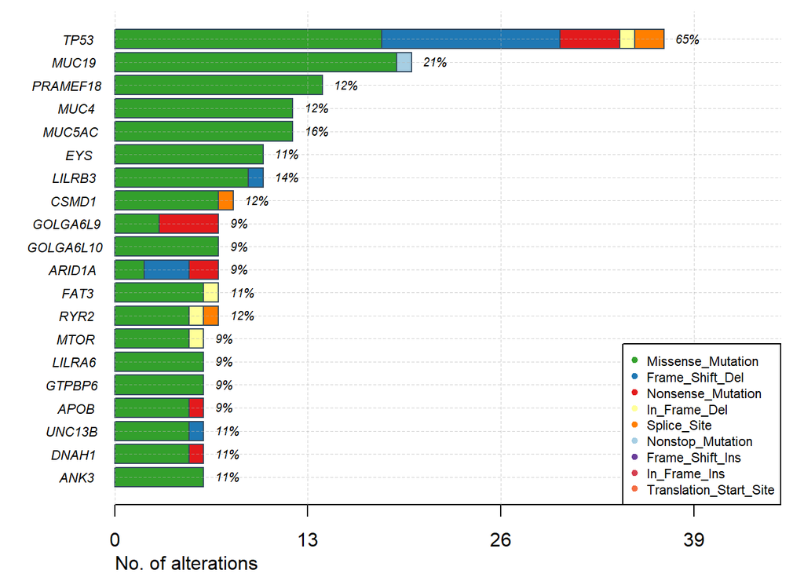

```r
mafbarplot(maf =  laml_NCB)
```

#### By Treatment

##### Nivo

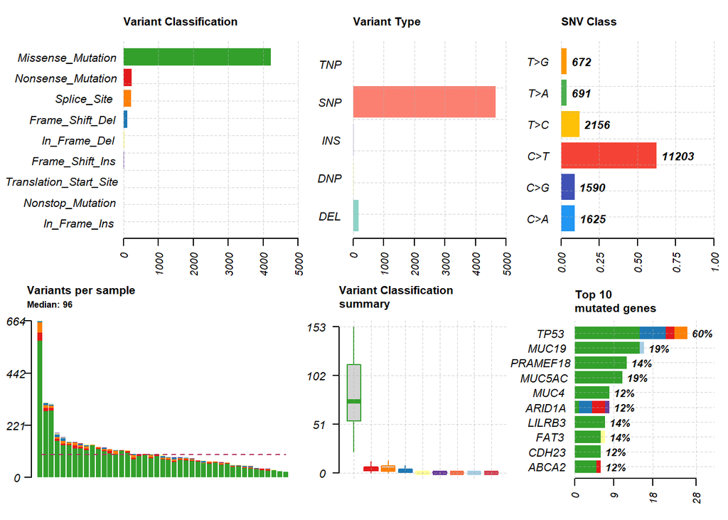

```r
## Nivo
plotmafSummary(maf = laml_nivo, rmOutlier = TRUE, addStat = 'median', dashboard = TRUE, titvRaw = FALSE)
```

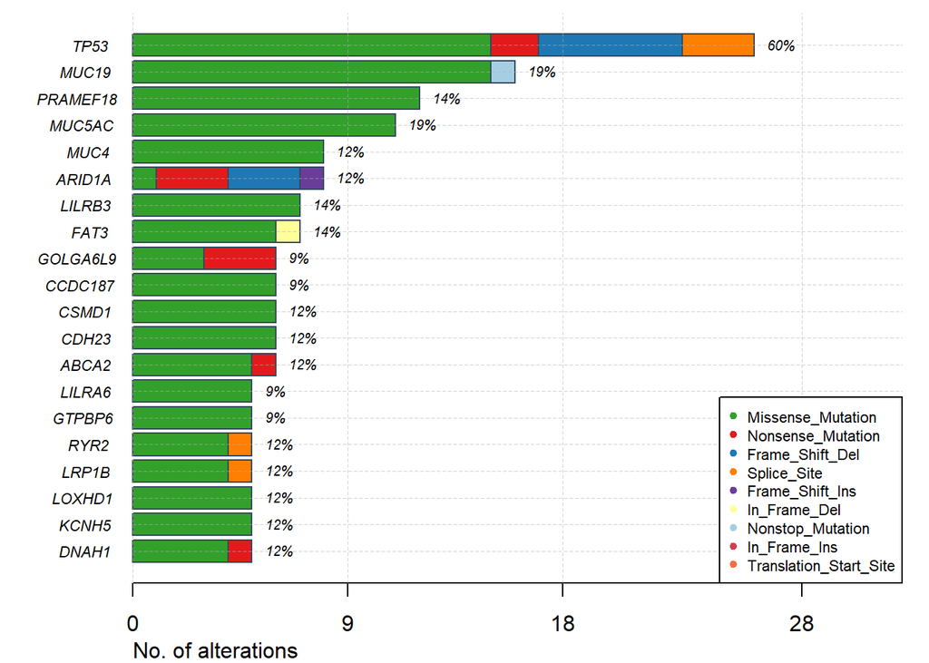

```r
mafbarplot(maf =  laml_nivo)
```

##### Combo

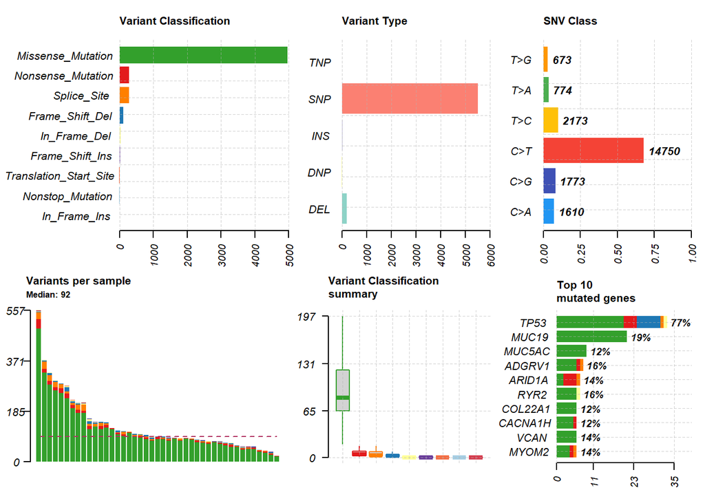

```r
## Combo
plotmafSummary(maf = laml_combo, rmOutlier = TRUE, addStat = 'median', dashboard = TRUE, titvRaw = FALSE)
```

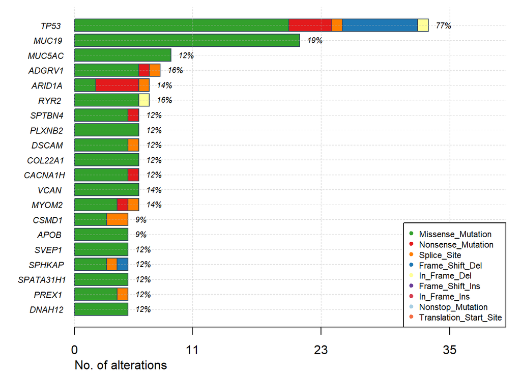

```r
mafbarplot(maf =  laml_combo)
```

# Oncoprints

Oncoprints (or “oncoplots” as the wrapper function in `maftools` is called) summarize complex genomic features of a given dataset.

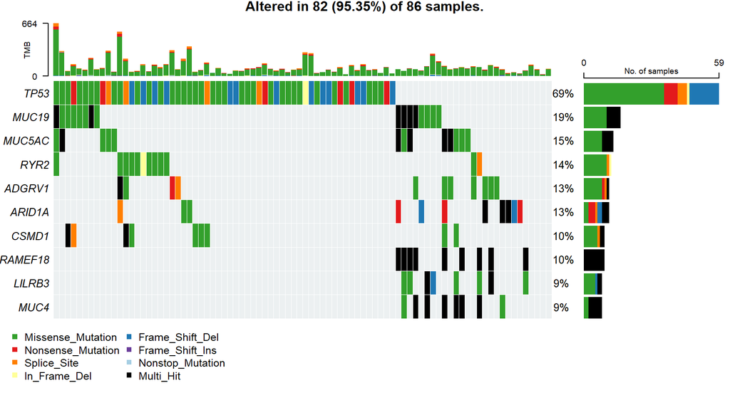

```r
#oncoplot for top ten mutated genes.
oncoplot(maf = laml_tum, top = 10)
```

These are the key features and how they are interpreted:

- Columns represent individual patients.
  - Reading column-wise, you can see the collection of alterations in a patient’s tumor for the given set of genes.
  - The bar plot on the top is a count of tumor mutation burden per patient, color-coded by mutation type.
- Rows are altered genes.
  - Alterations are color-coded to indicate their type (e.g. mutation, deletion, insertion)
  - Genes can be further annotated with key features (e.g. high impact/likely pathogenic mutations, germline variants, etc.)
- The bar plot on the right summarizes alterations in a given gene for the entire dataset.
- Many more features and annotations can be added to further characterize the dataset.

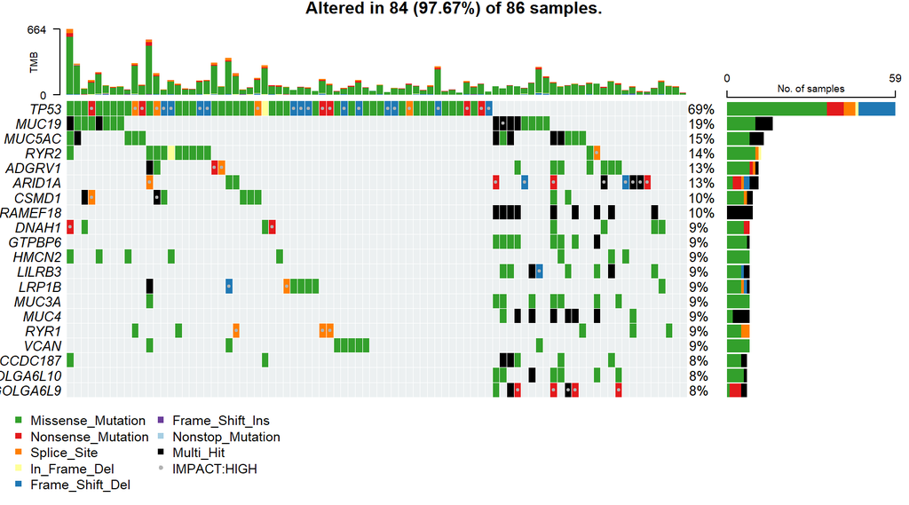

```r
# Highlight by specific attribute in MAF file
oncoplot(maf = laml_tum,
         additionalFeature = c("IMPACT", "HIGH"))
```

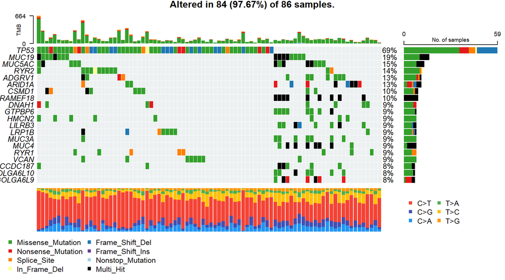

```r
# Add transitions/transversions
oncoplot(maf = laml_tum, draw_titv = TRUE)
```

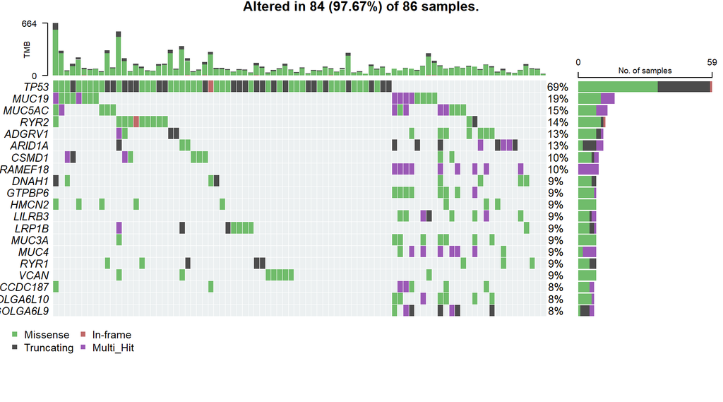

```r
# cBioPortal alteration nomenclature
oncoplot(maf = laml_tum, cBioPortal = TRUE)
```

## Oncoprints by clinical data

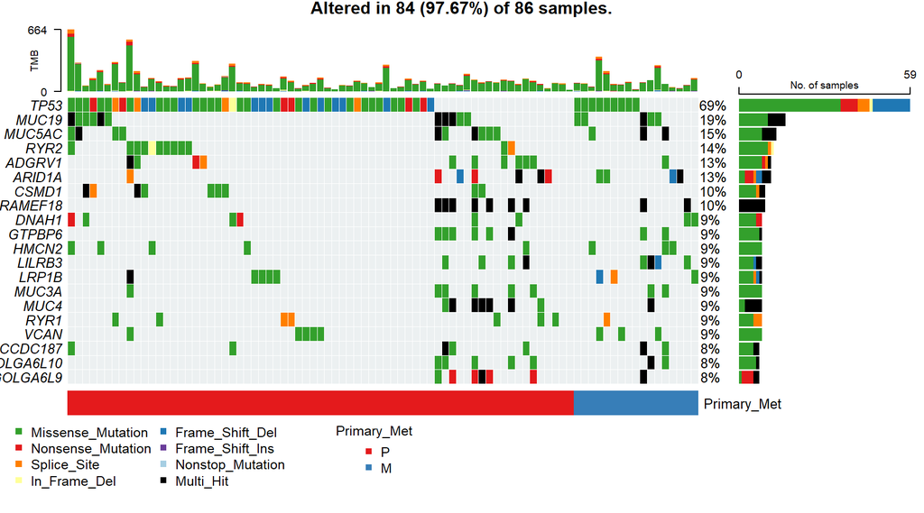

```r
##Primary vs metastatic sites
oncoplot(maf = laml_tum, clinicalFeatures = 'Primary_Met', sortByAnnotation = TRUE)
```

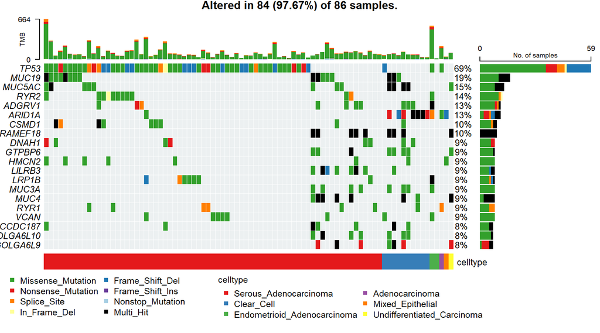

```r
## Cell type
oncoplot(maf = laml_tum, clinicalFeatures = 'celltype', sortByAnnotation = TRUE)
```

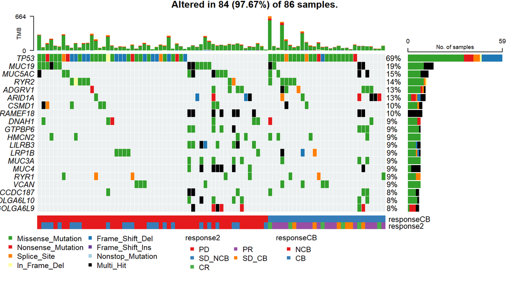

```r
## ICI response
oncoplot(maf = laml_tum, clinicalFeatures = c('responseCB','response2'), sortByAnnotation = TRUE)
```

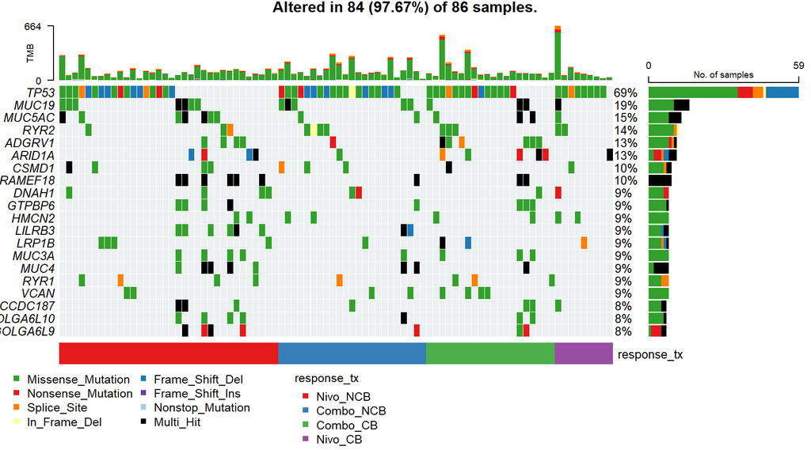

```r
## ICI response and treatment
oncoplot(maf = laml_tum, clinicalFeatures = 'response_tx', sortByAnnotation = TRUE)
```

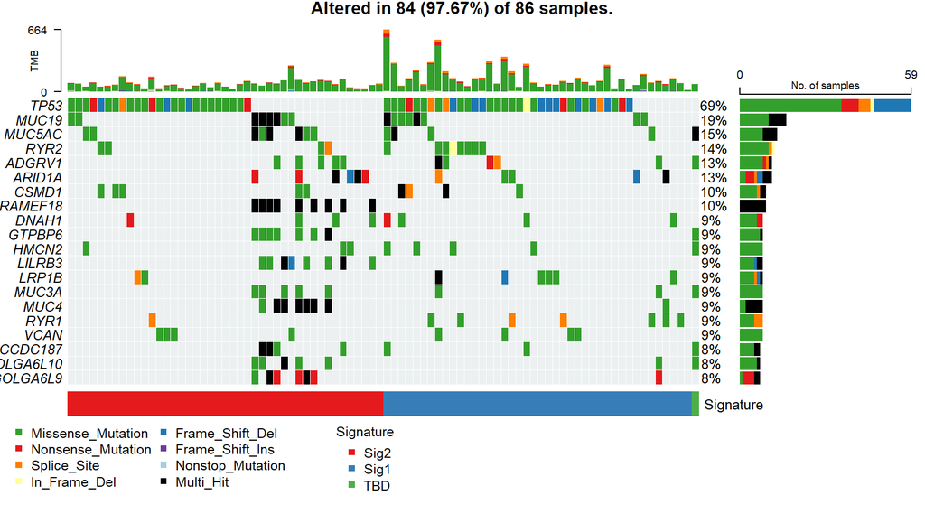

```r
## Mutational signature
oncoplot(maf = laml_tum, clinicalFeatures = 'Signature', sortByAnnotation = TRUE)
```

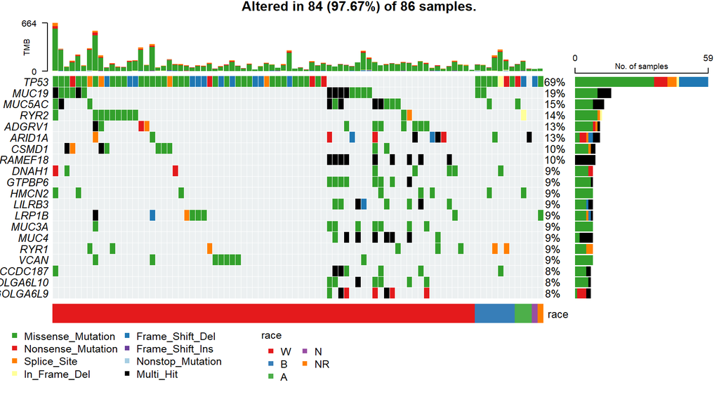

```r
## Race
oncoplot(maf = laml_tum, clinicalFeatures = 'race', sortByAnnotation = TRUE)
```

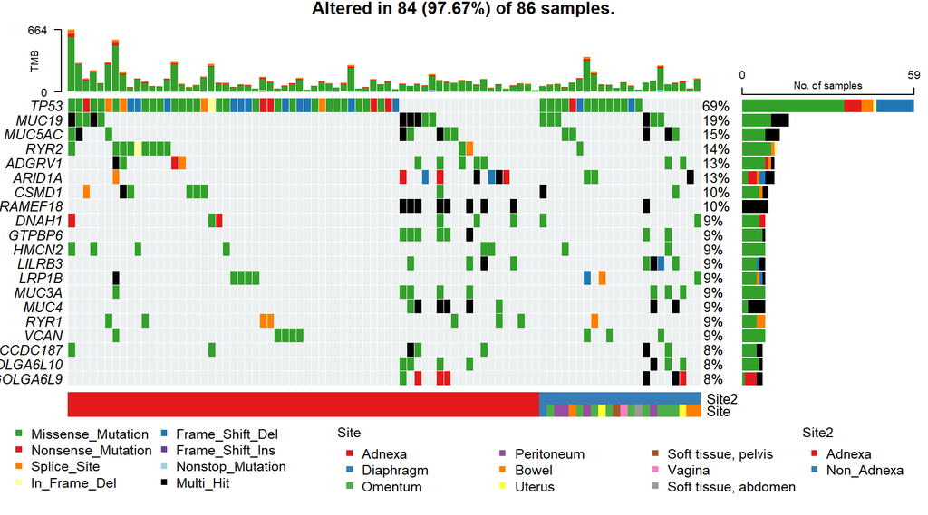

```r
## Site
oncoplot(maf = laml_tum, clinicalFeatures = c('Site2','Site'), sortByAnnotation = TRUE)
```

## Oncogenic signaling pathways

`sigpw` plots enrichment for known oncogenic signaling pathways as defined in TCGA, [Sanchez/Vega et al](https://pubmed.ncbi.nlm.nih.gov/29625050/).

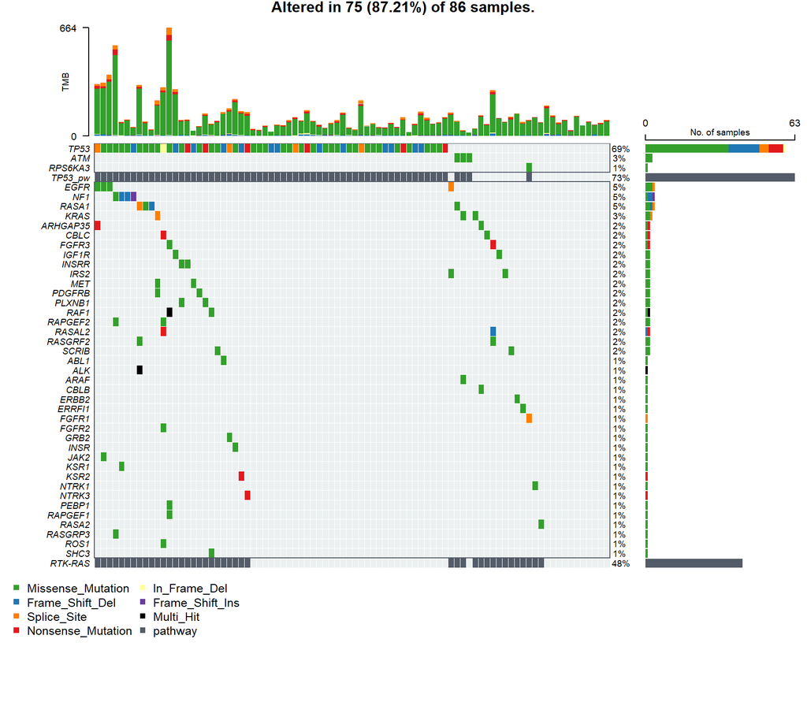

```r
# Plot genes in 2 top oncogenic signaling pathways
oncoplot(maf = laml_tum, pathways = "sigpw", gene_mar = 8, fontSize = 0.6, topPathways = 2)
```

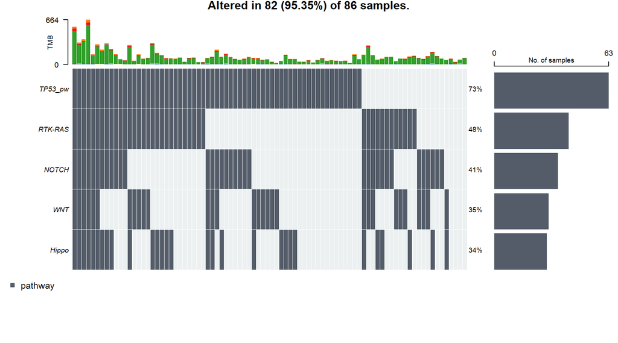

```r
# Collapse to just plot the pathways, now top 5
oncoplot(maf = laml_tum, pathways = "sigpw", gene_mar = 8, fontSize = 0.6, topPathways = 5,
         collapsePathway = TRUE)
```

### Pathways by Response

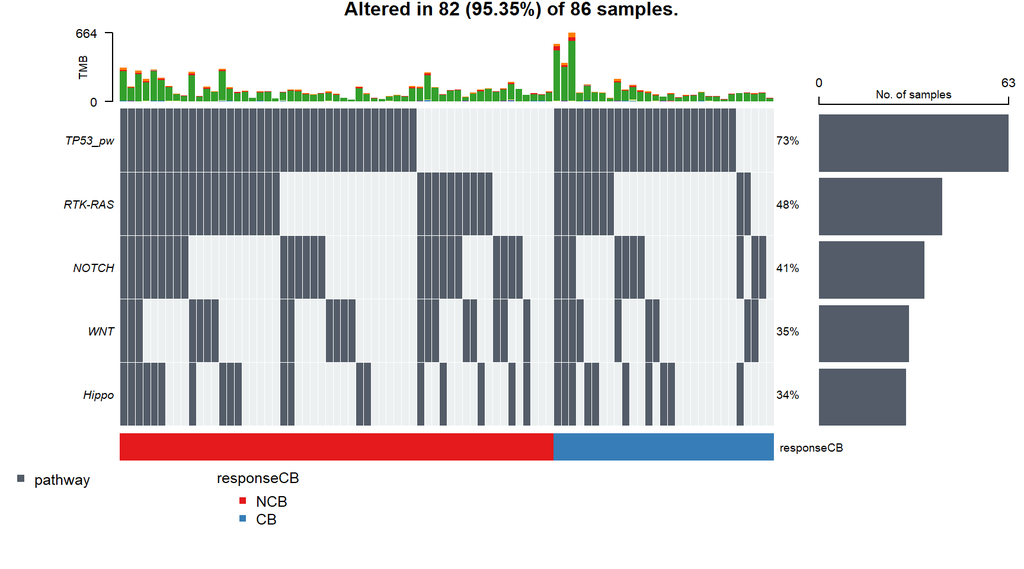

```r
# Response
oncoplot(maf = laml_tum, pathways = "sigpw", gene_mar = 8, fontSize = 0.6, topPathways = 5,
         collapsePathway = TRUE,
         clinicalFeatures = 'responseCB', sortByAnnotation = TRUE)
```

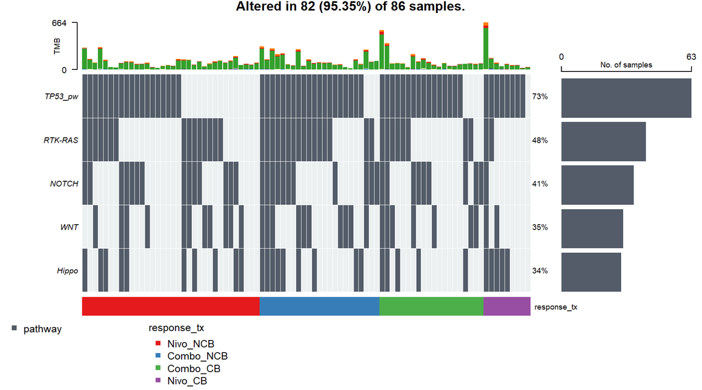

```r
# Response by treatment
oncoplot(maf = laml_tum, pathways = "sigpw", gene_mar = 8, fontSize = 0.6, topPathways = 5,
         collapsePathway = TRUE,
         clinicalFeatures = 'response_tx', sortByAnnotation = TRUE)
```

### Pathways by Histology

Since these are the top pathways for the whole cohort, they may be masking histologically-specific pathways.

This is where it is useful to subset the data. Here I am plotting the top pathways for serous and all non-serous patients separately.

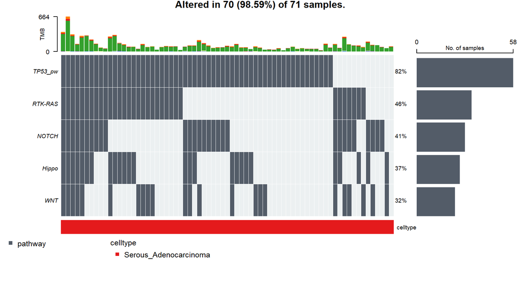

```r
# Serous
oncoplot(maf = laml_ser, pathways = "sigpw", gene_mar = 8, fontSize = 0.6, topPathways = 5,
         collapsePathway = TRUE,
         clinicalFeatures = 'celltype')
```

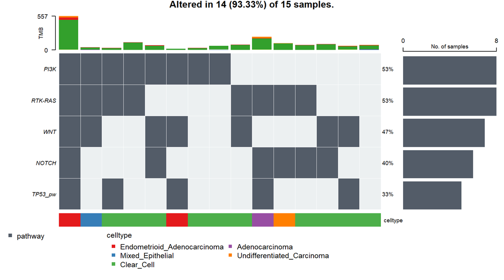

```r
# Non-serous
oncoplot(maf = laml_other, pathways = "sigpw", gene_mar = 8, fontSize = 0.6, topPathways = 5,
         collapsePathway = TRUE,
         clinicalFeatures = 'celltype')
```

## Biological processes of known tumor drivers

`smgbp` plots enrichment for pan-cancer significantly mutated genes, classified by biological processes, per [Bailey et al](https://pubmed.ncbi.nlm.nih.gov/29625053/).

Here are the top 2 biological processes of known drivers

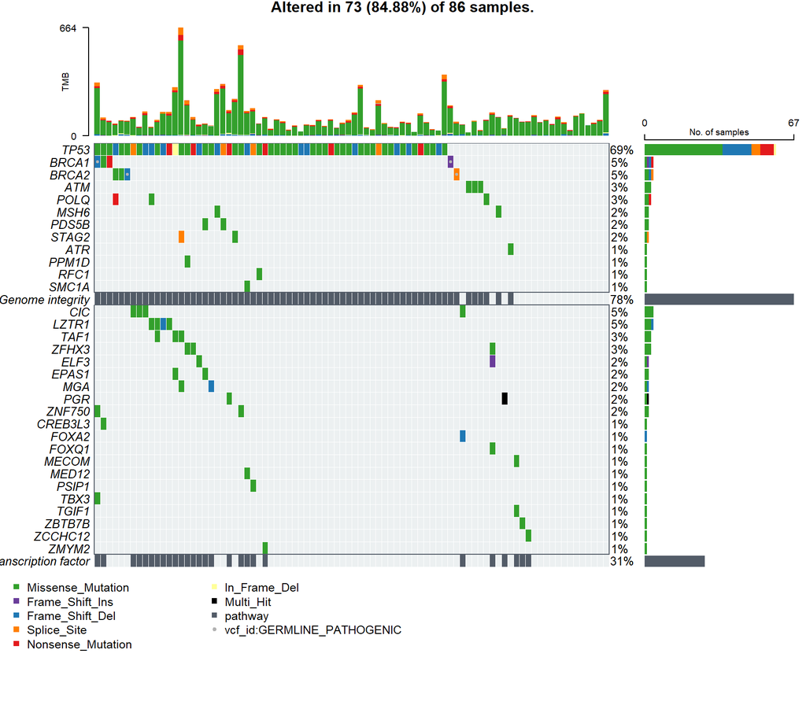

```r
# Note that I have highlighted the BRCA1/2 germline variants
oncoplot(maf = laml_tum, pathways = "smgbp", gene_mar = 8, fontSize = 0.8, topPathways = 2,
         additionalFeature = c("vcf_id", "GERMLINE_PATHOGENIC"))
```